# stock_data

Kanru Wang

```r
#install.packages("fst")
library(fst)
library(ggplot2)
library(data.table)
library(magrittr)
library(tidyverse)
library(readr)
library(TTR)
library(zoo)
```

```r
monthly_world_val = fst("C:/Users/wangka3/Desktop/learning/R_exercise/monthly_world_val.fst")
daily_US_prices = fst("C:/Users/wangka3/Desktop/learning/R_exercise/daily_US_prices.fst")
```

# Enterprise Value to Sales

- Calculate each company’s yearly median enterprise value to sales ratio, displayed as a point.
- Divide companies into two groups: U.S. and the rest of the world.
- Display by sector, by year.
- Each line represents the median of companies’ yearly median enterprise value to sales ratio.
- Zoomed to y axis range (-1, 40), but points outside the graph and in range (-5, 2000) are all used to calculate the positions of lines.

```r
EVTS_RAW = data.table(
  DATE = monthly_world_val[['DATE']],
  TICKER = monthly_world_val[['TICKER']],
  COUNTRY = monthly_world_val[['COUNTRY']],
  SECTOR = monthly_world_val[['SECTOR']],
  EV = monthly_world_val[['EV']],
  SALES = monthly_world_val[['SALES']]
)
```

```r
EVTS = EVTS_RAW %>%
  mutate(EVTS = EV/SALES,
         US_vs_Others = ifelse(.$COUNTRY == "United States", "U.S.", "Others"),
         YEAR = format(as.Date(.$DATE, format="%Y-%m-%d"),"%Y")) %>%
  select(TICKER, US_vs_Others, SECTOR, YEAR, EVTS) %>%
  filter(!is.na(SECTOR)) %>%  # Exclude na
  filter(SECTOR != "EXCLUDE") %>%  # Exclude "EXCLUDE"
  group_by(TICKER, US_vs_Others, SECTOR, YEAR) %>%
  summarize(ticker_yearly_median_EVTS = median(EVTS)) %>%
  filter(ticker_yearly_median_EVTS > - 5,  # Exclude extreme values
         ticker_yearly_median_EVTS < 2000)
#quantile(EVTS$ticker_yearly_median_EVTS, c(0.005, 0.01, 0.99, 0.995), na.rm = TRUE)
```

- US companies’ enterprise value to sales ratios seem to be usually higher.
- Year 2000 Internet Bubble can be seen.
- Some sectors have much higher enterprise value to sales ratios.
- Blue dots represent U.S. and red dots represent the rest of the world.

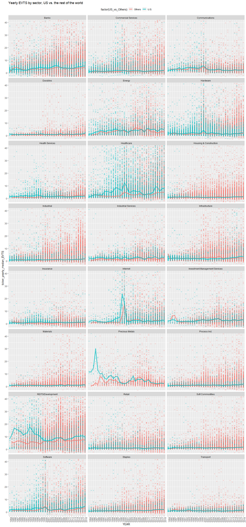

```r
ggplot(EVTS, aes(x = YEAR, y = ticker_yearly_median_EVTS,
                 colour = factor(US_vs_Others),
                 group = factor(US_vs_Others))) +
  geom_point(alpha = 0.2) +
  stat_summary(aes(y = ticker_yearly_median_EVTS),
               fun.y = median, geom = "line", size = 1.5, alpha = 0.7) +
  coord_cartesian(ylim = c(-1, 40)) +  # Zoom in
  facet_wrap( ~ SECTOR, ncol = 3) +
  theme(axis.text.x = element_text(angle = 90, size = 10),
        legend.position="top") +
  ggtitle("Yearly EVTS by sector, US vs. the rest of the world")
```

# Create a daily total return price index for the largest 500 stocks (at each point in time) listed on the US market.

```r
INDEX_RAW = data.table(
  DATE = daily_US_prices[['DATE']],
  MARKET_CAP = daily_US_prices[['MARKET_CAP']],
  TICKER = daily_US_prices[['TICKER']],
  PRICE =  daily_US_prices[['PRICE']]
)
```

### Option 1: creating an index without including dividends, i.e. sum(market cap for top 500 companies)

```r
INDEX_1 = INDEX_RAW %>%
  group_by(DATE) %>%
  top_n(n = 500, wt = MARKET_CAP) %>%
  summarize(sum_market_cap = sum(MARKET_CAP))
```

### Option 2: creating a Total Return index, i.e. sum(initial volume of issued stocks x adj price, for top 500 companies)

#### We need to get the volume of issued stocks when a ticker first appeared in the dataset.

```r
ticker_first_appear = INDEX_RAW %>%
  group_by(TICKER) %>%
  summarize(DATE = min(DATE)) # first_appear_date
```

```r
volume_of_stocks_beginning =
  merge(x = ticker_first_appear, y = INDEX_RAW,
        by = c("TICKER", "DATE"), all.x = TRUE) %>%
  mutate(volume_of_stocks = MARKET_CAP / PRICE) %>%
  select(TICKER, volume_of_stocks)
```

#### Daily largest 500 stocks are still determined by Market Cap.

```r
INDEX_2 = merge(x = INDEX_RAW, y = volume_of_stocks_beginning,
                by = "TICKER", all.x = TRUE) %>%
  mutate(market_cap_plus_dividends = PRICE * volume_of_stocks) %>%
  group_by(DATE) %>%
  top_n(n = 500, wt = MARKET_CAP) %>%
  summarize(sum_market_cap_plus_dividends = sum(market_cap_plus_dividends))
```

#### Import S&P 500 Total Return Index downloaded from Yahoo Finance.

```r
SP500TR <- read_csv("C:/Users/wangka3/Desktop/learning/R_exercise/SP500TR.csv",
    col_types = cols(DATE = col_date(format = "%d/%m/%Y")))
colnames(SP500TR)[2] = "SP500"
```

#### Apply index divisor to our index in order to align our index with S&P 500 Total Return.

```r
index_divisor_1 = INDEX_1$sum_market_cap[1] / SP500TR$SP500[1]
INDEX_1_aligned_with_SP500TR = INDEX_1 %>% mutate(index_1 = sum_market_cap / index_divisor_1)
```

```r
index_divisor_2 = INDEX_2$sum_market_cap_plus_dividends[1] / SP500TR$SP500[1]
INDEX_2_aligned_with_SP500TR = INDEX_2 %>%
  mutate(index_2 = sum_market_cap_plus_dividends / index_divisor_2)
```

#### Plot

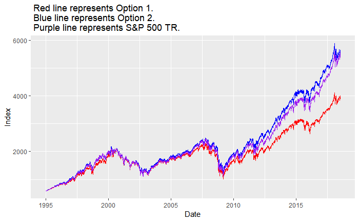

```r
ggplot() +
  geom_line(data = INDEX_1_aligned_with_SP500TR,
            aes(x = DATE, y = index_1), color = "red") +
  geom_line(data = INDEX_2_aligned_with_SP500TR,
            aes(x = DATE, y = index_2), color = "blue") +
  geom_line(data = SP500TR,
            aes(x = DATE, y = SP500), color = "purple") +
  xlab('Date') +
  ylab('Index') +
  ggtitle(" Red line represents Option 1.\n Blue line represents Option 2.\n Purple line represents S&P 500 TR.")
```

#### Option 2 is much more similar to S&P 500 TR than Option 1 is. Dividend is important.

### Calculate the (annualized and compound) 3Y rolling return of the index and plot against the (annualized and compound) 3Y rolling return of the S&P 500, for each day.

#### Expand to include non-trading days and fill non-trading days with the latest previous value.

```r
full_dates = as.data.table(seq(as.Date("1994-12-30"), as.Date("2018-07-19"), by="days"))
colnames(full_dates) = "DATE"
```

```r
expanded_to_non_trading_days_then_filled = full_dates %>%                        # Single column of dates
  merge(x = ., y = INDEX_1_aligned_with_SP500TR, by = "DATE", all.x = TRUE) %>%  # Merge Option 1
  merge(x = ., y = INDEX_2_aligned_with_SP500TR, by = "DATE", all.x = TRUE) %>%  # Merge Option 2
  merge(x = ., y = SP500TR, by = "DATE", all.x = TRUE) %>%                       # Merge S&P 500 TR
  mutate(index_1 = na.locf(.$index_1),  # Fill non-trading days with the latest previous value
         index_2 = na.locf(.$index_2),
         SP500 = na.locf(.$SP500)) %>%
  select(DATE, index_1, index_2, SP500)
```

#### Using the formula: index_today = index_3y_ago_today * (1 + x) ** 3

```r
annualised_and_compound_3y_rolling_return = expanded_to_non_trading_days_then_filled %>%
  mutate(index_1 = ROC(.$index_1, n = 365 * 3, type = "discrete"),
         index_2 = ROC(.$index_2, n = 365 * 3, type = "discrete"),
         SP500   = ROC(.$SP500, n = 365 * 3, type = "discrete")) %>%
  mutate(index_1 = (.$index_1 + 1) ** (1 / 3) - 1,
         index_2 = (.$index_2 + 1) ** (1 / 3) - 1,
         SP500   = (.$SP500 + 1) ** (1 / 3) - 1)
```

#### Plot

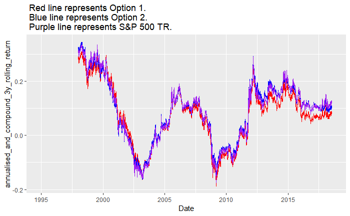

```r
ggplot() +
  geom_line(data = annualised_and_compound_3y_rolling_return,
            aes(x = DATE, y = index_1), color = "red") +
  geom_line(data = annualised_and_compound_3y_rolling_return,
            aes(x = DATE, y = index_2), color = "blue") +
  geom_line(data = annualised_and_compound_3y_rolling_return,
            aes(x = DATE, y = SP500), color = "purple") +
  xlab('Date') +
  ylab('annualised_and_compound_3y_rolling_return') +
  ggtitle(" Red line represents Option 1.\n Blue line represents Option 2.\n Purple line represents S&P 500 TR.")
```

### Summary table

[output not shown]

#### See below for calculation details of the table.

#### Cumulative Total Return

```r
(cumu_total_return_index_1 =
  tail(INDEX_1_aligned_with_SP500TR$index_1, 1) / head(INDEX_1_aligned_with_SP500TR$index_1, 1) - 1)
```

```
[1] 5.930621
```

```r
(cumu_total_return_index_2 =
  tail(INDEX_2_aligned_with_SP500TR$index_2, 1) / head(INDEX_2_aligned_with_SP500TR$index_2, 1) - 1)
```

```
[1] 8.810893
```

```r
(cumu_total_return_SP500TR =
  tail(SP500TR$SP500, 1) / head(SP500TR$SP500, 1) - 1)
```

```
[1] 8.597731
```

#### Cumulative Total Return p.a.

```r
horizon = as.numeric(tail(INDEX_RAW$DATE, 1) - head(INDEX_RAW$DATE, 1)) / 365
```

```r
(cumu_total_return_index_1_pa = (cumu_total_return_index_1 + 1) ** (1 / horizon) - 1)
```

```
[1] 0.08561451
```

```r
(cumu_total_return_index_2_pa = (cumu_total_return_index_2 + 1) ** (1 / horizon) - 1)
```

```
[1] 0.1017427
```

```r
(cumu_total_return_SP500TR_pa = (cumu_total_return_SP500TR + 1) ** (1 / horizon) - 1)
```

```
[1] 0.1007162
```

#### Annualised Volatility of Daily Returns

```r
annualised_volatility_of_daily_returns = function(index) {
  daily_return = ROC(index, n = 1, na.pad = FALSE, type = "discrete")      # Get daily change
  daily_return_excluded_non_trading_days = daily_return[daily_return != 0] # Exclude non-trading days whose change is 0
  return(sd(daily_return_excluded_non_trading_days) * (252 ** 0.5))      # 252 trading days per year
}
```

```r
annualised_volatility_of_daily_returns(INDEX_1_aligned_with_SP500TR$index_1)
```

```
[1] 0.1838022
```

```r
annualised_volatility_of_daily_returns(INDEX_2_aligned_with_SP500TR$index_2)
```

```
[1] 0.1754804
```

```r
annualised_volatility_of_daily_returns(SP500TR$SP500)
```

```
[1] 0.1852883
```

# Chart the 30d average annualised standard deviation of daily returns for a market capitalization weighted index made of all US stocks in the top quintile of market capitalisation (at each point in time).

#### Calculated on the index of *Option 2* only.

#### First need to add a threshould for filtering the top quintile.

```r
INDEX_2_COUNTED = merge(x = INDEX_RAW, y = volume_of_stocks_beginning,
                             by = "TICKER", all.x = TRUE) %>%
  mutate(market_cap_plus_dividends = PRICE * volume_of_stocks) %>%
  add_count(DATE) %>%
  mutate(how_many_in_top_quintile = round(n / 5))
```

#### Should achieve the same effect of “Rank() Over Partition By” in SQL.

```r
INDEX_2_RANKED = data.table(INDEX_2_COUNTED)[, MARKET_CAP_Rank := frank(- MARKET_CAP),by = "DATE"]
# Accuracy verified by the code in below which should yield the same result.
#INDEX_2_RANKED = transform(INDEX_2_COUNTED,
#                           MARKET_CAP_Rank = ave(- MARKET_CAP,
#                                                 DATE,
#                                                 FUN = function(x) rank(x, ties.method = "first")))
```

#### Filtering and then calculating sum_market_cap_plus_dividends.

```r
INDEX_2_TOP_QUINTILE =
  INDEX_2_RANKED[INDEX_2_RANKED$how_many_in_top_quintile >= INDEX_2_RANKED$MARKET_CAP_Rank, ] %>%
  group_by(DATE) %>%
  summarize(sum_market_cap_plus_dividends = sum(market_cap_plus_dividends))
```

#### Edit this function for our need to have a 30 day rolling window.

```r
annualised_30_days_rolling_volatility_of_daily_returns = function(df, col_name_of_index) {
  df$daily_return = ROC(df[, col_name_of_index], n = 1, na.pad = TRUE, type = "discrete") # Get daily change
  df = df[!is.na(df$daily_return), ]                                  # Exclude the first row whose value is NA
  df = df[df$daily_return != 0, ]                                     # Exclude non-trading days whose change is 0
  df$rolling_volatility = rollapply(data = df$daily_return, width = 30, FUN = sd, fill = NA)
  df$rolling_volatility = df$rolling_volatility * (252 ** 0.5)        # 252 trading days per year
  return(df)
}
# Below is nicer but doesn't take a df and therefore will not return a date column.
#annualised_30_days_rolling_volatility_of_daily_returns = function(index) {
#  daily_return = ROC(index, n = 1, na.pad = FALSE, type = "discrete")      # Get daily change
#  daily_return_excluded_non_trading_days = daily_return[daily_return != 0] # Exclude non-trading days whose change is 0
#  rolling_volatility = rollapply(data = daily_return_excluded_non_trading_days, width = 30, FUN = sd)
#  return(rolling_volatility * (252 ** 0.5))                                # 252 trading days per year
#}
annualised_30_days_rolling_volatility_of_daily_returns_result =
  annualised_30_days_rolling_volatility_of_daily_returns(INDEX_2_TOP_QUINTILE, "sum_market_cap_plus_dividends")
```

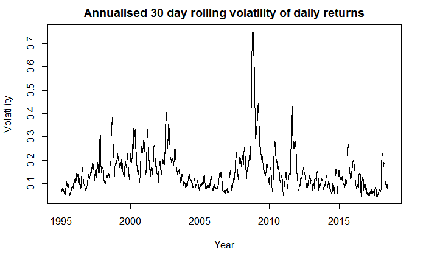

```r
plot(y = annualised_30_days_rolling_volatility_of_daily_returns_result$rolling_volatility,
     x = annualised_30_days_rolling_volatility_of_daily_returns_result$DATE,
     type = "l", xlab = "Year", ylab = "Volatility",
     main = "Annualised 30 day rolling volatility of daily returns")
```

# If 5% of the portfolio is invested in Microsoft, try to hedge out the risk of downward price movements in the most capital efficient way.

#### The first way is to buy a put option to give us the right to sell. It will be a prefect hedge, but need to pay an option premium.

#### The second way is designed to only hedge out a big part of the market risk. It is assumed that we are holding Microsoft because it is expected to grow in the short term, and the specific risk of Microsoft can be ignored. The implementation is to short a basket of stocks that are highly correlated with Microsoft. Therefore, our holding of Microsoft will be exposed to a well reduced amount of market risk. See below for the process of picking out the highly correlated stocks.

#### For each stock, calculate its daily change for the last five years (“five” is arbitrarily picked to represent the recent price movement).

```r
INDEX_RAW_SPREAD = INDEX_RAW %>%
  select(- MARKET_CAP) %>%
  filter(DATE >= "2013-07-19") %>%
  spread(key = TICKER, value = PRICE)
EACH_STOCK_DAILY_CHANGE = INDEX_RAW_SPREAD %>%
  arrange(DATE) %>%
  select(- DATE) %>%
  map(~ ROC(., n = 1, na.pad = TRUE, type = "discrete"))
# MSFT-US
```

#### Calculate the Pearson correlation between Microsoft and each other stock.

```r
EACH_STOCK_CORRELATION_WITH_MSFT = EACH_STOCK_DAILY_CHANGE %>%
  map(~ cor(., EACH_STOCK_DAILY_CHANGE$`MSFT-US`, use = "complete.obs", method = "pearson")) %>%
  unlist
```

#### Plot correlation

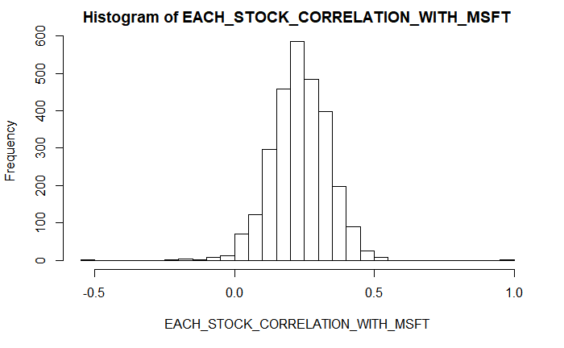

```r
hist(EACH_STOCK_CORRELATION_WITH_MSFT, breaks = 50)
```

#### What do we have here? Google, Intel, PayPal, Intuit, Accenture, Mastercard, Texas Instruments, Honeywell, and Adobe. They are all similar to Microsoft in terms of market capitalisation size and sector. Make sense.

```r
tail(sort(EACH_STOCK_CORRELATION_WITH_MSFT), 10)
```

```
  ADBE-US    HON-US    TXN-US     MA-US    ACN-US   INTU-US   PYPL-US   INTC-US  GOOGL-US   MSFT-US
0.5017814 0.5072801 0.5089609 0.5105380 0.5109208 0.5128353 0.5154859 0.5327716 0.5335116 1.0000000
```

#### Now make a small portfolio for shorting using the nine stocks with equal weighting (“nine” is arbitrarily picked). It is beyond my knowledge how to optimize the weighting.

```r
SHORT_PORTFOLIO = data.table(
  `ADBE-US` = EACH_STOCK_DAILY_CHANGE[['ADBE-US']],
  `HON-US` = EACH_STOCK_DAILY_CHANGE[['HON-US']],
  `TXN-US` = EACH_STOCK_DAILY_CHANGE[['TXN-US']],
  `MA-US` = EACH_STOCK_DAILY_CHANGE[['MA-US']],
  `ACN-US` = EACH_STOCK_DAILY_CHANGE[['ACN-US']],
  `INTU-US` = EACH_STOCK_DAILY_CHANGE[['INTU-US']],
  `PYPL-US` = EACH_STOCK_DAILY_CHANGE[['PYPL-US']],
  `INTC-US` = EACH_STOCK_DAILY_CHANGE[['INTC-US']],
  `GOOGL-US` = EACH_STOCK_DAILY_CHANGE[['GOOGL-US']]
)
```

```r
SHORT_PORTFOLIO$mean = rowMeans(SHORT_PORTFOLIO, na.rm = TRUE, dims = 1)
```

#### This small portfolio for shorting has a 0.69 correlation with Microsoft.

```r
cor(EACH_STOCK_DAILY_CHANGE$`MSFT-US`, SHORT_PORTFOLIO$mean, use = "complete.obs", method = "pearson")
```

```
[1] 0.6925226
```